# 303.3. Color selections

For the Rubin Science Platform at data.lsst.cloud.  
Data Release: [Data Preview 1](https://dp1.lsst.io/)  
Container Size: large  
LSST Science Pipelines version: r29.2.0  
Last verified to run: 2026-06-12  
Repository: github.com/lsst/tutorial-notebooks

**Learning objective:** Explore high redshift galaxy color selection with DP1.

**LSST data products:** `Object` table, `deep_coadd` images

**Packages:** `lsst.rsp.get_tap_service`, `pyvo`, `astroquery`

**Credit:** This notebook benefited from discussions with Dan Taranu, John Franklin Crenshaw, and the Rubin LSST photometric redshift commissioning team.

**Get Support:** Everyone is encouraged to ask questions or raise issues in the [Support Category](https://community.lsst.org/c/support) of the Rubin Community Forum. Rubin staff will respond to all questions posted there.

## 1. Introduction

Color selections have served as a key method of identifying different populations of galaxies for decades. Especially at redshift z > 2.5, the Lyman-break is a strong spectral feature that is exploited to identify galaxies at high redshift in ground-based imaging. Lyman-break selections make use of the fact that intergalactic hydrogen in the foreground absorbs all the light of background galaxies that is emitted blueward of the Lyman limit (912A) or at very high redshifts, Lyman-alpha (1216A). [More details about why this works can be found at this blog-post.](http://candels-collaboration.blogspot.com/2012/08/how-to-find-distant-galaxies.html)

Thus, galaxies at high redshifts can be identified by their very red colors between filters that bridge the Lyman break feature (and are named after their selection method as Lyman break galaxies or LBGs). Since intergalactic hydrogen absorbs the light blueward of the Lyman break, the flux of true z ~ 3 galaxies drops as the Lyman-break redshifts into the LSST u-band, and at z ~ 4 in the LSST g-band.

This notebook demonstrates the Lyman break color selection on DP1 data for galaxies at z ~ 4 as an example (referred to as g-band dropouts), and provides some validation metrics for its performance. It makes use of color selections defined and used in the literature with data from facilities with similar filter sets (band pass shapes and effective wavelengths). These are using the Canada-France-Hawaii Telescope Legacy Survey (CFHTLS) as presented in [Hildebrandt et al., 2009](https://ui.adsabs.harvard.edu/abs/2009A%26A...498..725H/abstract) and [van der Burg et al., 2010](https://ui.adsabs.harvard.edu/abs/2010A%26A...523A..74V/abstract). A similar selection was performed using Subaru Hyper-Suprime Cam data in [Ono et al. 2018](https://ui.adsabs.harvard.edu/abs/2018PASJ...70S..10O/abstract).

**Related tutorials:** See also the 303-series tutorials on galaxy science, specifically the 303.1 tutorial that overviews the various galaxy photometry measurements produced by the LSST pipelines, and their science use cases.

### 1.1. Import packages

Import common scientific analysis packages `numpy`, `matplotlib`, and `astropy`.

Import LSST Science Pipelines package utilities for remote data access `lsst.rsp`.

Import `pyvo` packages for working with the virtual observatory cutout service.

Import `astroquery` to allow access to publicly available external science products (spectroscopic redshift catalogs).

```python
import io
import numpy as np
import matplotlib.pyplot as plt
from astropy.io import fits
from astropy.coordinates import SkyCoord
import astropy.units as u
from astropy.visualization import ZScaleInterval, LinearStretch, ImageNormalize

from lsst.rsp import get_tap_service
from lsst.rsp.utils import get_pyvo_auth

from pyvo.dal.adhoc import SodaQuery, DatalinkResults
from astroquery.vizier import Vizier
```

### 1.2. Define parameters and functions

Create an instance of the TAP service, and store the authorization as `session`.

```python
tap_service = get_tap_service("tap")
session = get_pyvo_auth()
```

## 2. Query and photometric validation

Set the target field to be the ECDFS, where many spectroscopic redshift data exist.

```python
target_ra = 53.125
target_dec = -28.1
```

Define a query to retrieve galaxies from the object table using the `extendedness`=1 flag. Search around the center of the field using a 0.5 degree search radius to cover the full field. To ensure good detections, include the $S/N > 10$ cut on the $i$-band.

```python
query = (
    "SELECT obj.objectId, obj.coord_ra, obj.coord_dec, "
    "obj.u_sersicFlux, obj.u_sersicFluxErr, "
    "obj.g_sersicFlux, obj.g_sersicFluxErr, "
    "obj.r_sersicFlux, obj.r_sersicFluxErr, "
    "obj.i_sersicFlux, obj.i_sersicFluxErr, "
    "obj.z_sersicFlux, obj.z_sersicFluxErr "
    "FROM dp1.Object AS obj "
    "WHERE (obj.i_sersicFlux / obj.i_sersicFluxErr > 10) "
    "AND (obj.i_extendedness = 1) "
    "AND (obj.sersic_no_data_flag = 0) "
    "AND (obj.i_cModel_flag = 0) "
    "AND CONTAINS(POINT('ICRS', obj.coord_ra, obj.coord_dec), "
    f"CIRCLE('ICRS', {target_ra}, {target_dec}, 0.5)) = 1"
)
```

Run the query.

```python
job = tap_service.submit_job(query)
job.run()
job.wait(phases=['COMPLETED', 'ERROR'])
print('Job phase is', job.phase)
assert job.phase == 'COMPLETED'
```

```
Job phase is COMPLETED
```

Retrieve the query results and save as an `astropy` table.

```python
tab = job.fetch_result().to_table()
print(f"Retrieved {len(tab)} galaxies from Rubin imaging.")
```

```
Retrieved 113859 galaxies from Rubin imaging.
```

Galaxy colors may be inaccurate for galaxies whose S/N is very low in one or more filters. To ensure that (in particular) the dropout color is robust, if the S/N is less than 1 then set the flux to the flux error (this will use the 1-sigma lower limit to the color, replacing flux with the error floor if S/N < 1). Convert the nJy flux to ABmag, using definition of -2.5 * log10(nJy) + 31.4.

```python
filters = ['u', 'g', 'r', 'i']

with np.errstate(divide='ignore', invalid='ignore'):
    for filt in filters:
        flux_robust = np.where(tab[f'{filt}_sersicFlux']
                               < tab[f'{filt}_sersicFluxErr'],
                               tab[f'{filt}_sersicFluxErr'],
                               tab[f'{filt}_sersicFlux'])
        tab[f'{filt}_mag_robust'] = -2.50 * np.log10(flux_robust) + 31.4
```

Store these robust colors as new columns in the table.

```python
tab['g_minus_r'] = tab['g_mag_robust'] - tab['r_mag_robust']
tab['r_minus_i'] = tab['r_mag_robust'] - tab['i_mag_robust']
```

### 2.1. LBG selection

Now, perform the color selection to identify the high-redshift galaxy candidates. Use a typical Lyman break selection for a camera with similar filter properties to the LSST (e.g. Ono et al. 2018). The selection requires very red g-r colors (to identify galaxies with strong Lyman breaks), and relatively blue r-i colors (typical of star-forming galaxies with little dust, and which excludes stars).

Use the selection criteria for z~4 LBGs defined in Ono et al. 2018, which are:

1. g - r > 1.0
2. r - i < 1.0
3. g - r > 1.5 * (r - i) + 0.8

Also, add another criteria requiring that the u-band flux be undetected (S/N < 3), since all u-band flux should also be absorbed by the intergalactic medium since it is blueward of the Lyman limit at z > 3.

```python
is_z4_lbg = ((tab['g_minus_r'] > 1.0)
             & (tab['u_sersicFlux'] / tab['u_sersicFluxErr'] < 3)
             & (tab['r_minus_i'] < 1.0)
             & (tab['g_minus_r'] > 1.5 * tab['r_minus_i'] + 0.8))

print(f"Identified {np.sum(is_z4_lbg)} photometric LBG candidates.")
```

```
Identified 1838 photometric LBG candidates.
```

### 2.2. Validation data

This section will fetch an archival spectroscopic redshift catalog to use as a validation dataset. Use data from the [VANDELS](http://vandels.inaf.it/) spectroscopic redshift catalog (a deep VLT/VIMOS spectroscopic survey of the Cosmic Assembly Near-infrared Deep Extragalactic Survey or CANDELS). This survey was very deep and targeted a large number of high redshift galaxies making it a good single-catalog choice for validation.

#### 2.2.1. Fetch spec-z catalog

Use the `astroquery` package's `VizieR` service to retrieve the public catalog. Information on the catalog and its contents can be found in [Garilli et al. 2021](https://ui.adsabs.harvard.edu/abs/2021A%26A...647A.150G/abstract). The [catalog ID to search in `VizieR`](https://ui.adsabs.harvard.edu/abs/2022yCat..36470150G/abstract) can be found on adsabs.harvard.edu in connection to the data release paper. VANDELS took data in two extragalactic deep fields. Pull the table of data obtained in the ECDFS as `vandels_cdfs`, which is the first table in the return (index 0).

```python
vandels_survey = Vizier(columns=['**'], catalog="J/A+A/647/A150")
vandels_survey.ROW_LIMIT = -1
all_tables = vandels_survey.get_catalogs("J/A+A/647/A150")
vandels_cdfs = all_tables[0]
```

```python
is_vandels_z4 = ((vandels_cdfs['zsp'] >= 3.7)
                 & (vandels_cdfs['zsp'] <= 4.5)
                 & (vandels_cdfs['q_zsp'] >= 3))
vandels_truth = vandels_cdfs[is_vandels_z4]
print(f"Found {len(vandels_truth)} high-confidence VANDELS sources at z~4")
```

```
Found 133 high-confidence VANDELS sources at z~4
```

#### 2.2.2. Cross-match

Perform the LBG selection on the Rubin data, then match to objects with the same coordinates in the VANDELS catalog to see what true high redshift galaxies passed the LBG selection and which failed.

```python
coord_v = SkyCoord(ra=vandels_truth['RAJ2000'], dec=vandels_truth['DEJ2000'], unit='deg')
coord_r = SkyCoord(ra=tab['coord_ra'], dec=tab['coord_dec'], unit='deg')

idx_rubin, d2d, _ = coord_v.match_to_catalog_sky(coord_r)
match_mask = d2d < 1.0 * u.arcsec
```

Below, isolate the matched sources in the two datasets. Then define success and failure masks based on whether the matched objects passed the LBG color selection.

```python
matched_rubin_indices = idx_rubin[match_mask]
vandels_in_rubin = tab[matched_rubin_indices]
v_matched_truth = vandels_truth[match_mask]

lbg_success_mask = is_z4_lbg[matched_rubin_indices]
failed_lbg = ~lbg_success_mask

print(f"VANDELS z~4 sources detected in Rubin catalog: {len(matched_rubin_indices)}")
print(f"VANDELS sources successfully recovered by LBG selection: {np.sum(lbg_success_mask)}")
print(f"VANDELS sources missed by LBG selection: {np.sum(failed_lbg)}")
```

```
VANDELS z~4 sources detected in Rubin catalog: 51
VANDELS sources successfully recovered by LBG selection: 27
VANDELS sources missed by LBG selection: 24
```

### 2.3 Plot color color diagrams

First, store some shorthand parameters for the colors in the selection, and for parameters to color-code the galaxies by.

```python
v_g_minus_r = vandels_in_rubin['g_minus_r']
v_r_minus_i = vandels_in_rubin['r_minus_i']
v_i_mag = vandels_in_rubin['i_mag_robust']
v_z_spec = v_matched_truth['zsp']
v_gerr = vandels_in_rubin['g_sersicFluxErr']
```

Define the selection window from Ono et al. 2018 to plot in the color color diagram.

```python
intersect_x = (1.0 - 0.8) / 1.5
x_diag = np.linspace(intersect_x, 1.0, 50)
y_diag = 1.5 * x_diag + 0.8
```

Define a figure for the color color diagram. Plot all the Rubin galaxies from the query in Section 2.1 (gray), all Rubin galaxies that satisfy the LBG color selection (blue), and the true spectroscopically confirmed high-redshift galaxies as bold colored symbols. Stars indicate the true high-redshift galaxies that meet the color selection and plus signs are the true high-redshift galaxies that do not.

#### 2.3.1 Magnitude dependence

Color-code the galaxies by their i-band magnitude, to see if spectroscopically confirmed galaxies that are missed by the LBG selection might be faint, suggesting photometric scatter could contribute to missed galaxies.

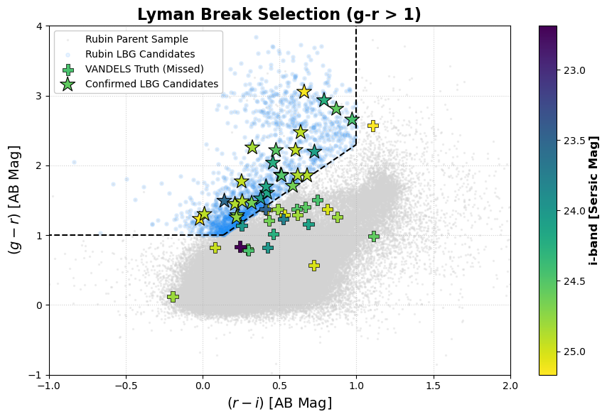

```python
fig, ax = plt.subplots(figsize=(9, 6))

vmin, vmax = np.nanmin(v_i_mag), np.nanmax(v_i_mag)

ax.scatter(tab['r_minus_i'], tab['g_minus_r'], s=2, color='lightgray',
           alpha=0.3, label='Rubin Parent Sample')
ax.scatter(tab['r_minus_i'][is_z4_lbg], tab['g_minus_r'][is_z4_lbg],
           s=15, color='dodgerblue', alpha=0.1, label='Rubin LBG Candidates')

sc = ax.scatter(v_r_minus_i[failed_lbg], v_g_minus_r[failed_lbg],
                s=120, c=v_i_mag[failed_lbg], cmap='viridis', vmin=vmin, vmax=vmax,
                marker='P', edgecolor='k', linewidth=0.5, zorder=4,
                label='VANDELS Truth (Missed)')

sc = ax.scatter(v_r_minus_i[lbg_success_mask], v_g_minus_r[lbg_success_mask],
                s=250, c=v_i_mag[lbg_success_mask], cmap='viridis', vmin=vmin, vmax=vmax,
                marker='*', edgecolor='k', linewidth=0.8, zorder=5,
                label='Confirmed LBG Candidates')

cbar = plt.colorbar(sc, ax=ax)
cbar.set_label('i-band [Sersic Mag]', fontsize=12, fontweight='bold')
cbar.ax.invert_yaxis()

ax.plot([-1.5, intersect_x], [1.0, 1.0], color='black', linestyle='--', lw=1.5)
ax.plot(x_diag, y_diag, color='black', linestyle='--', lw=1.5)
ax.plot([1.0, 1.0], [2.3, 4.0], color='black', linestyle='--', lw=1.5)

ax.set_xlim(-1.0, 2.0)
ax.set_ylim(-1.0, 4.0)
ax.set_xlabel('$(r - i)$ [AB Mag]', fontsize=14)
ax.set_ylabel('$(g - r)$ [AB Mag]', fontsize=14)
ax.set_title('Lyman Break Selection (g-r > 1)', fontsize=16, fontweight='bold')

handles, labels = ax.get_legend_handles_labels()
ax.legend(handles, labels, loc='upper left', framealpha=1)
ax.grid(True, linestyle=':', alpha=0.6)

plt.tight_layout()
plt.show()
```

#### 2.3.2 Imaging depth dependence

Color-code the galaxies by their g-band flux error, a proxy for the depth of the g-band imaging, to see if spectroscopically confirmed galaxies that are missed by the LBG selection might because the g-band imaging was not deep enough to provide a robust lower limit on the dropout color.

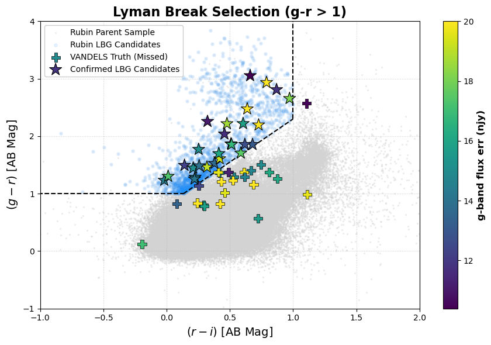

```python
v_gerr = vandels_in_rubin['g_sersicFluxErr']

fig, ax = plt.subplots(figsize=(9, 6))

vmin, vmax = np.nanmin(v_gerr), 20

ax.scatter(tab['r_minus_i'], tab['g_minus_r'], s=2, color='lightgray',
           alpha=0.3, label='Rubin Parent Sample')
ax.scatter(tab['r_minus_i'][is_z4_lbg], tab['g_minus_r'][is_z4_lbg],
           s=15, color='dodgerblue', alpha=0.1, label='Rubin LBG Candidates')

sc = ax.scatter(v_r_minus_i[failed_lbg], v_g_minus_r[failed_lbg],
                s=120, c=v_gerr[failed_lbg], cmap='viridis', vmin=vmin, vmax=vmax,
                marker='P', edgecolor='k', linewidth=0.5, zorder=4,
                label='VANDELS Truth (Missed)')

sc = ax.scatter(v_r_minus_i[lbg_success_mask], v_g_minus_r[lbg_success_mask],
                s=250, c=v_gerr[lbg_success_mask], cmap='viridis', vmin=vmin, vmax=vmax,
                marker='*', edgecolor='k', linewidth=0.8, zorder=5,
                label='Confirmed LBG Candidates')

cbar = plt.colorbar(sc, ax=ax)
cbar.set_label('g-band flux err (njy)', fontsize=12, fontweight='bold')

ax.plot([-1.5, intersect_x], [1.0, 1.0], color='black', linestyle='--', lw=1.5)
ax.plot(x_diag, y_diag, color='black', linestyle='--', lw=1.5)
ax.plot([1.0, 1.0], [2.3, 4.0], color='black', linestyle='--', lw=1.5)

ax.set_xlim(-1.0, 2.0)
ax.set_ylim(-1.0, 4.0)
ax.set_xlabel('$(r - i)$ [AB Mag]', fontsize=14)
ax.set_ylabel('$(g - r)$ [AB Mag]', fontsize=14)
ax.set_title('Lyman Break Selection (g-r > 1)', fontsize=16, fontweight='bold')

handles, labels = ax.get_legend_handles_labels()
ax.legend(handles, labels, loc='upper left', framealpha=1)
ax.grid(True, linestyle=':', alpha=0.6)

plt.tight_layout()
plt.show()
```

> Figure 2: Like Figure 1, except that confirmed galaxies are color coded by g-band flux uncertainty as a proxy for variations in the depth or integration time in the g-band filter imaging. Their unsuccessful selection does not show any trend with image depth (which might be expected if galaxies in shallower imaging have smaller lower limits to the g-r color).

#### 2.3.3 Redshift dependence

Since there is no obvious trend with magnitude or imaging depth, color code the spectroscopically confirmed high-redshift galaxies by their spectroscopic redshift. At the higher redshift end of the selection window, the g-band flux is completely undetected when the filter probes blueward of the Lyman limit (912A). But at lower end of the redshift selection window the g-band will probe blueward of Lyman alpha (1216A) and redward of the Lyman limit (912A) but will only be partially absorbed because of the Lyman-alpha forest. The amount of flux can vary. In the plot below, color-code by spectroscopic redshift to see if the bluer galaxies are at lower redshifts.

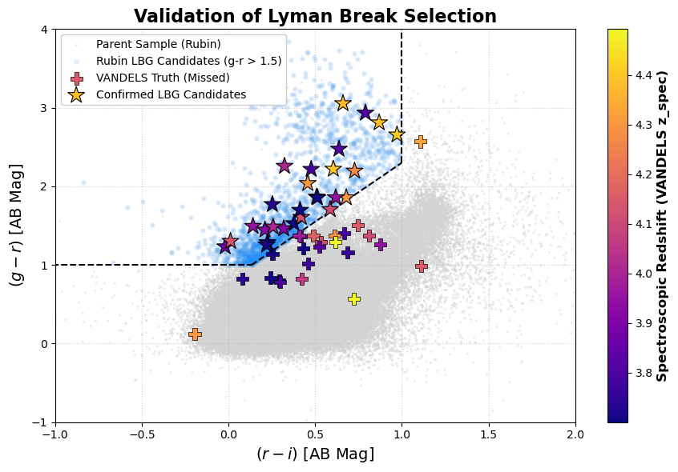

```python
vmin, vmax = np.nanmin(v_z_spec), np.nanmax(v_z_spec)

fig, ax = plt.subplots(figsize=(9, 6))

ax.scatter(tab['r_minus_i'], tab['g_minus_r'], s=2, color='lightgray', alpha=0.3,
           label='Parent Sample (Rubin)')
ax.scatter(tab['r_minus_i'][is_z4_lbg], tab['g_minus_r'][is_z4_lbg],
           s=15, color='dodgerblue', alpha=0.1, label='Rubin LBG Candidates (g-r > 1.5)')

sc = ax.scatter(v_r_minus_i[failed_lbg], v_g_minus_r[failed_lbg],
                s=120, c=v_z_spec[failed_lbg], cmap='plasma', vmin=vmin, vmax=vmax,
                marker='P', edgecolor='k', linewidth=0.5, zorder=4,
                label='VANDELS Truth (Missed)')

sc = ax.scatter(v_r_minus_i[lbg_success_mask], v_g_minus_r[lbg_success_mask],
                s=250, c=v_z_spec[lbg_success_mask], cmap='plasma', vmin=vmin, vmax=vmax,
                marker='*', edgecolor='k', linewidth=0.8, zorder=5,
                label='Confirmed LBG Candidates')

cbar = plt.colorbar(sc, ax=ax)
cbar.set_label('Spectroscopic Redshift (VANDELS z_spec)', fontsize=12, fontweight='bold')

ax.plot([-1.5, intersect_x], [1.0, 1.0], color='black', linestyle='--', lw=1.5)
ax.plot(x_diag, y_diag, color='black', linestyle='--', lw=1.5)
ax.plot([1.0, 1.0], [2.3, 4.0], color='black', linestyle='--', lw=1.5)

ax.set_xlim(-1.0, 2.0)
ax.set_ylim(-1.0, 4.0)
ax.set_xlabel('$(r - i)$ [AB Mag]', fontsize=14)
ax.set_ylabel('$(g - r)$ [AB Mag]', fontsize=14)
ax.set_title('Validation of Lyman Break Selection', fontsize=16, fontweight='bold')

handles, labels = ax.get_legend_handles_labels()
ax.legend(handles, labels, loc='upper left', framealpha=1)
ax.grid(True, linestyle=':', alpha=0.6)

plt.tight_layout()
plt.show()
```

#### 2.3.4 Interpretation

The color selection identifies a large number of true high-redshift galaxies. A number of confirmed galaxies fall outside the selection window. While the color selection is not designed to be 100% inclusive of high redshift galaxies, it should select a relatively pure sample with few interlopers. Galaxies may reside outside the selection box do not seem to trend with any single property tested in Section 2.3.1-2.3.3, but may be caused by a combination of photometric scatter, variation in depth of the g-band imaging, and that the strength of the g-r color will vary across the redshift selection window. Other effects also contribute: dust attenuation in the galaxy will redden the restframe UV probed by the r-i color and similarly decreasing the brightness of the observed r band flux (thus making the g-r color less robustly constrained). A possible effect from DP1 could also be the known issue of a small fraction of [red-wavelength photon leak in the g-band](https://dp1.lsst.io/products/known_issues_and_subtleties.html#g-band-red-leak-excess-long-wavelength-transmission) which might contaminate the dropout filter with redder-wavelength light from the galaxy. This effect is exacerbated by the higher operating temperature of LSSTComCam during commissioning and is expected to be resolved in DP2 LSSTCam data.

This exemplifies how photometric selection is statistical in nature. While the physics of the Lyman break creates the strong spectral feature that can be exploited for a simple selection, the photometric noise and intrinsic galaxy variations will scatter the galaxy colors in and out of the selection box.

## 3. Visual inspection

Finally, generate image cutouts to visually inspect both the missed and confirmed subsets of spectroscopically confirmed galaxies. This validation is necessary to confirm the fidelity of the sample.

```python
missed_v_truth = v_matched_truth[failed_lbg]
missed_r_data = vandels_in_rubin[failed_lbg]

confirmed_v_truth = v_matched_truth[lbg_success_mask]
confirmed_r_data = vandels_in_rubin[lbg_success_mask]
```

Define a function to generate image cutouts in 4 filters for visual inspection.

```python
def plot_cutouts(r_data, v_data, n_max=10, title_label="Candidate"):
    n_plot = min(len(r_data), n_max)
    if n_plot == 0:
        print(f"No sources to plot for {title_label}.")
        return

    filters = ['u', 'g', 'r', 'i']
    fig, axes = plt.subplots(n_plot, len(filters), figsize=(12, 3.5 * n_plot))
    if n_plot == 1:
        axes = [axes]

    print(f"Requesting cutouts for {n_plot} sources: {title_label}...")

    for row_idx in range(n_plot):
        ra = r_data['coord_ra'][row_idx]
        dec = r_data['coord_dec'][row_idx]
        obj_id = r_data['objectId'][row_idx]
        z_spec = v_data['zsp'][row_idx]
        g_r = r_data['g_minus_r'][row_idx]
        r_i = r_data['r_minus_i'][row_idx]

        cutout_query = f"""
        SELECT lsst_band, access_url
        FROM ivoa.ObsCore
        WHERE dataproduct_subtype = 'lsst.deep_coadd'
        AND obs_collection = 'LSST.DP1'
        AND CONTAINS(POINT('ICRS', {ra}, {dec}), s_region) = 1
        """

        job = tap_service.submit_job(cutout_query)
        job.run()
        job.wait()
        coadds = job.fetch_result().to_table()

        for col_idx, f in enumerate(filters):
            ax = axes[row_idx][col_idx]
            band_match = coadds[coadds['lsst_band'] == f]

            if len(band_match) > 0:
                try:
                    datalink_url = band_match['access_url'][0]
                    dl_result = DatalinkResults.from_result_url(datalink_url, session=session)
                    sq = SodaQuery.from_resource(dl_result,
                                                 dl_result.get_adhocservice_by_id("cutout-sync"),
                                                 session=session)
                    sq.circle = (ra * u.deg, dec * u.deg, 10.0 / 3600.0 * u.deg)

                    cutout_bytes = sq.execute_stream().read()
                    hdul = fits.open(io.BytesIO(cutout_bytes))
                    img_array = hdul[1].data

                    norm = ImageNormalize(img_array, interval=ZScaleInterval(),
                                          stretch=LinearStretch())
                    ax.imshow(img_array, origin='lower', cmap='gray', norm=norm)
                    cy, cx = img_array.shape[0]//2, img_array.shape[1]//2
                    ax.add_patch(plt.Circle((cx, cy), radius=6, color='cyan',
                                            fill=False, lw=1.5, alpha=0.7))

                except Exception:
                    ax.text(0.5, 0.5, 'SODA Error', ha='center', va='center',
                            transform=ax.transAxes, color='red')
            else:
                ax.text(0.5, 0.5, 'No Coverage', ha='center', va='center',
                        transform=ax.transAxes, color='red')

            ax.set_xticks([])
            ax.set_yticks([])
            if row_idx == 0:
                ax.set_title(f"{f}-band", fontsize=15, fontweight='bold')
            if col_idx == 0:
                label_str = f"z_sp: {z_spec: .2f}\nID: {obj_id}\ng-r: {g_r: .2f}\nr-i={r_i: .2f}"
                ax.set_ylabel(label_str, rotation=0, labelpad=70, ha='center', fontweight='bold')

    plt.tight_layout()
    plt.show()
```

Now plot the 4-filter cutouts for a few (5) real high redshift galaxies confirmed by VANDELS that were identified correctly in the Rubin color selection.

```
Total confirmed VANDELS LBGs available to plot: 27
Requesting cutouts for 5 sources: VANDELS high-z confirmations identified by Rubin color selection...
```

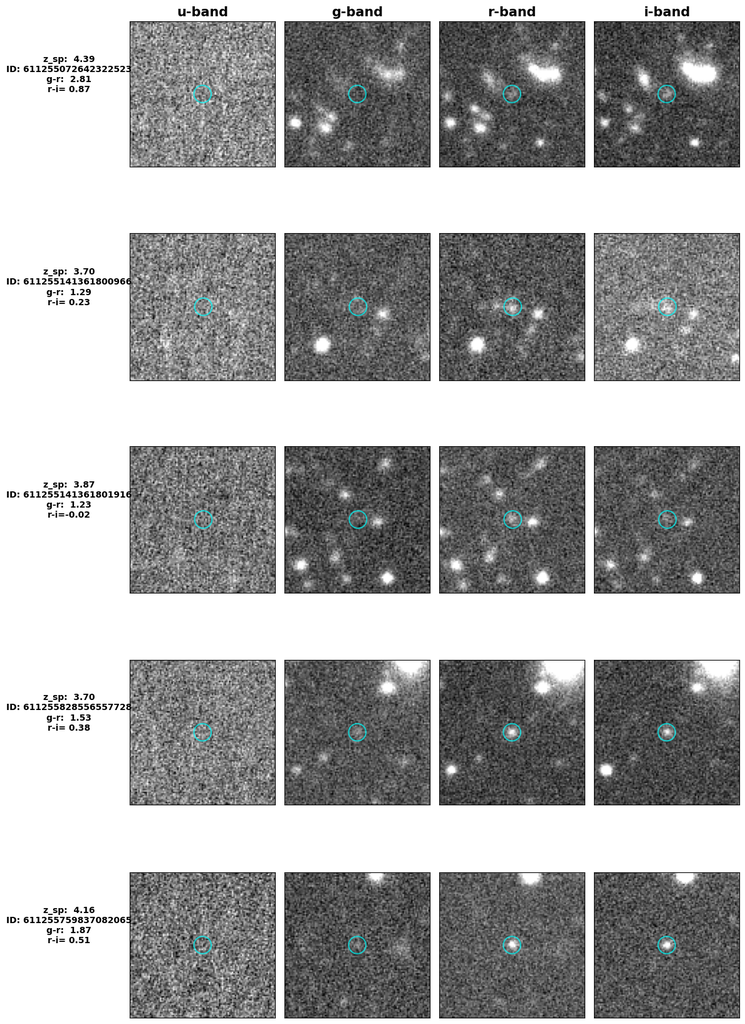

```python
print(f"Total confirmed VANDELS LBGs available to plot: {len(confirmed_r_data)}")

plot_cutouts(confirmed_r_data, confirmed_v_truth, n_max=5,
             title_label="VANDELS high-z confirmations identified by Rubin color selection")
```

> Figure 4: Deep coadd image cutouts of a few confirmed high-redshift galaxies that are selected as LBGs from the Rubin imaging. As expected for galaxies at z > 3.5, the galaxies are not detected in the u-band, their flux is significantly decreased in the g-band, and are detected in r and i-bands.

Optionally, also generate cutouts of the true high-redshift galaxies that were missed the color selection. Now plot the 4-filter cutouts for the real high redshift galaxies confirmed by VANDELS but that the Rubin color selection missed. They are a mix of galaxies with too-blue g-r colors and too-red r-i colors.

```python
# plot_cutouts(missed_r_data, missed_v_truth, n_max=5,
#              title_label="VANDELS high-z confirmations missed by Rubin color selection")
```

## 4. Interloper fraction

Below, select all Rubin objects at any redshift with a secure VANDELS ectroscopic redshift measurement (high quality only, `q_zsp` of 3 or 4; See Garilli et al. 2021). Use that full sample across all redshifts to investigate the interloper fraction of the Rubin color selection (this exercise is only informative above the magnitude limit of the VANDELS sample, and does not apply to fainter galaxies).

First, cross-match all galaxies for which VANDELS secured a robust redshift measurement with the Rubin objects from hte query in Section 2.

```python
is_vandels_hq = vandels_cdfs['q_zsp'] >= 3
vandels_all_hq = vandels_cdfs[is_vandels_hq]

coord_v_all = SkyCoord(ra=vandels_all_hq['RAJ2000'], dec=vandels_all_hq['DEJ2000'], unit='deg')
coord_r = SkyCoord(ra=tab['coord_ra'], dec=tab['coord_dec'], unit='deg')

idx_rubin_all, d2d_all, _ = coord_v_all.match_to_catalog_sky(coord_r)
match_mask_all = d2d_all < 1.0 * u.arcsec
```

For simplicity, make new arrays to hold the matched datasets.

```python
matched_rubin_all = tab[idx_rubin_all[match_mask_all]]
matched_v_all = vandels_all_hq[match_mask_all]

z_spec_all = matched_v_all['zsp']
i_mag_all = matched_rubin_all['i_mag_robust']
obj_ids_all = matched_rubin_all['objectId']
```

Now make a histogram of VANDELS galaxies with spectroscopic redshifts that met the Rubin LBG color selection, and investigate the interloper fraction among confirmed galaxies.

First, perform the color selection again on the parent sample of all VANDELS high-quality confirmations.

```python
is_selected_lbg = (
    (matched_rubin_all['g_minus_r'] > 1.0)
    & (matched_rubin_all['u_sersicFlux'] / matched_rubin_all['u_sersicFluxErr'] < 3)
    & (matched_rubin_all['r_minus_i'] < 1.0)
    & (matched_rubin_all['g_minus_r'] > 1.5 * matched_rubin_all['r_minus_i'] + 0.8))

selected_spec_z = matched_v_all['zsp'][is_selected_lbg]
```

Next, identify low-redshift interlopers that met the color selection criteria, and compare. Define the redshift window according to Ono et al. 2018 selection window of 3.2 < z < 4.5.

```python
failed_spec_z = selected_spec_z[selected_spec_z < 3.2]

print("Among the VANDELS spectroscopic sample:")
print(f"{len(selected_spec_z)} out of {len(matched_v_all['zsp'])} are color selected")
print(f"{len(failed_spec_z)} LBG candidates are confirmed low redshift interlopers, ")
print(f"indicating a {len(failed_spec_z)/len(matched_v_all['zsp'])*100: .2f}% interloper fraction")
```

[output not shown]

Next, plot the histogram along with the redshift selection window that was characterized by Ono et al. 2018. That study found that the HSC filterset and their color selection criteria (both very similar to Rubin's filters and the color selection used in this notebook) produces a selection window at 3.2 < z < 4.5.

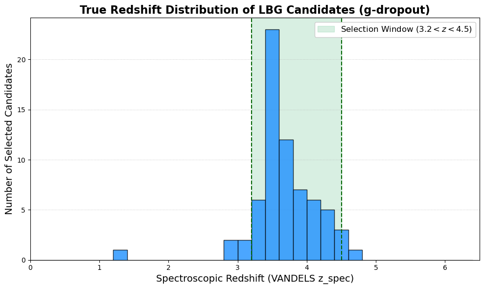

```python
fig, ax = plt.subplots(figsize=(10, 6))

z_bins = np.arange(0, 6.6, 0.2)

ax.hist(selected_spec_z, bins=z_bins, color='dodgerblue', edgecolor='black',
        alpha=0.8, zorder=3)

ax.axvspan(3.2, 4.5, color='mediumseagreen', alpha=0.2,
           label='Selection Window ($3.2 < z < 4.5$)')
ax.axvline(3.2, color='darkgreen', linestyle='--', linewidth=1.5, zorder=4)
ax.axvline(4.5, color='darkgreen', linestyle='--', linewidth=1.5, zorder=4)

ax.set_xlim(0, 6.5)
ax.set_xlabel('Spectroscopic Redshift (VANDELS z_spec)', fontsize=14)
ax.set_ylabel('Number of Selected Candidates', fontsize=14)
ax.set_title('True Redshift Distribution of LBG Candidates (g-dropout)',
             fontsize=16, fontweight='bold')

ax.legend(loc='upper right', fontsize=12, framealpha=1)
ax.grid(axis='y', linestyle=':', alpha=0.7, zorder=0)

plt.tight_layout()
plt.show()
```

> Figure 5: Histogram of the redshifts of all spectroscopically confirmed galaxies that enter the Lyman-break color selection, indicating a very low interloper fraction. The selection window with Rubin data matches the one characterized by Ono et al. 2018 (green) using HSC data and the same color criteria (3.2 < z < 4.5).